# Beer, Wine and Spirits

2020-10-20

```r
data<-read_csv(here::here("data", "cleaned_with_binary.csv")) #import data
attach(data)
```

```r
##MVN tests
library(CompQuadForm)

species1<-data[which(data$DGS_binary==1),]

species2<-data[which(data$DGS_binary==0),]

##MVN tests forDGS_binary==1
mvnorm.kur.test(species1[,2:6])
```

```
##
##  Multivariate Normality Test Based on Kurtosis
##
## data:  species1[, 2:6]
## W = 16, w1 = 0.7, df1 = 14.0, w2 = 1.1, df2 = 1.0, p-value = 0.1
```

```r
mvnorm.skew.test(species1[,2:6])
```

```
##
##  Multivariate Normality Test Based on Skewness
##
## data:  species1[, 2:6]
## U = 10, df = 5, p-value = 0.08
```

```r
##MVN tests forDGS_binary==0
mvnorm.kur.test(species2[,2:6])
```

```
##
##  Multivariate Normality Test Based on Kurtosis
##
## data:  species2[, 2:6]
## W = 12, w1 = 0.7, df1 = 14.0, w2 = 1.1, df2 = 1.0, p-value = 0.4
```

```r
mvnorm.skew.test(species2[,2:6])
```

```
##
##  Multivariate Normality Test Based on Skewness
##
## data:  species2[, 2:6]
## U = 0.7, df = 5, p-value = 1
```

##Split data

```r
DGS_binary<-as.factor(data$DGS_binary)

set.seed(100) # change to same value as before

sample.data<-sample.int(nrow(data), floor(.50*nrow(data)), replace = F)

train<- data[sample.data, ]

test <- data[-sample.data, ]

pred.test<-test[,"DGS_binary"]
```

##Recursive Binary Splitting

```r
##Use recursive binary splitting on training data
tree.class.train <- tree(factor(DGS_binary) ~ PF_Current + PF_Expected + BC_12months + BC_5years + BuyConditions, data=train)

summary(tree.class.train)
```

```
##
## Classification tree:
## tree(formula = factor(DGS_binary) ~ PF_Current + PF_Expected +
##     BC_12months + BC_5years + BuyConditions, data = train)
## Variables actually used in tree construction:
## [1] "BuyConditions" "PF_Current"    "BC_5years"     "PF_Expected"
## Number of terminal nodes:  8
## Residual mean deviance:  0.513 = 25.1 / 49
## Misclassification error rate: 0.123 = 7 / 57
```

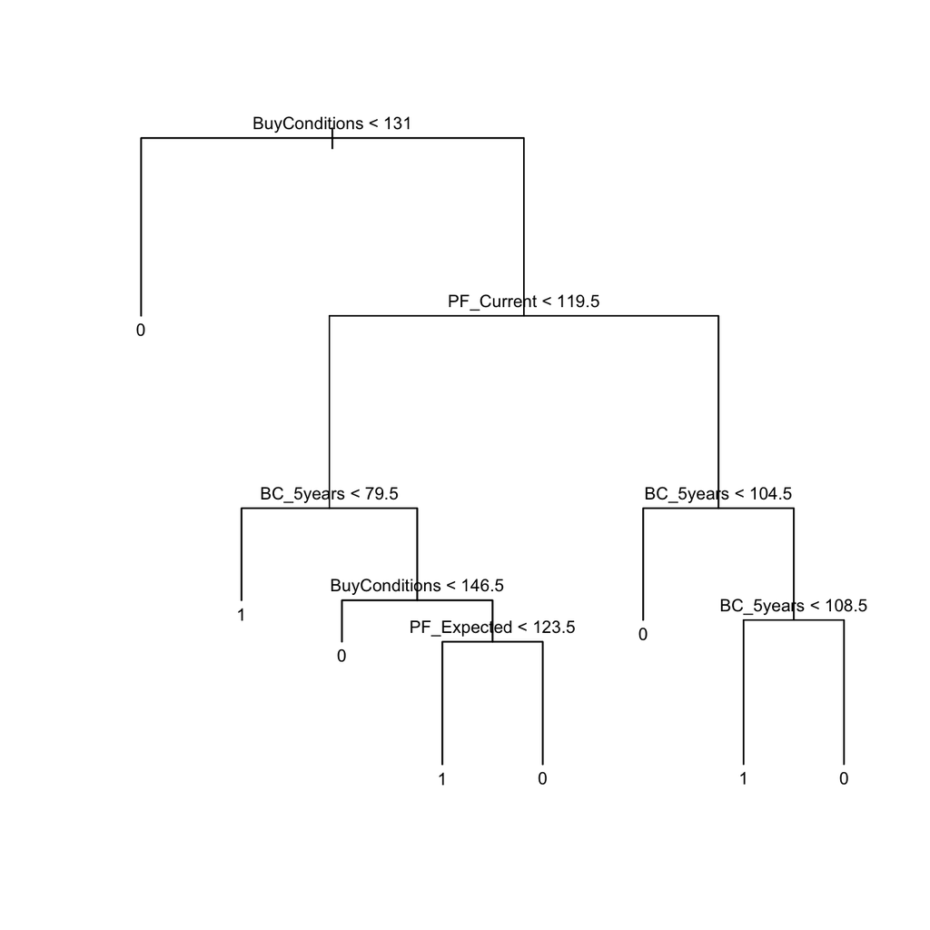

```r
##plot tree
plot(tree.class.train)

text(tree.class.train, cex=0.75, pretty=0)
```

```r
##find predicted classes for test data
tree.pred.test<-predict(tree.class.train, newdata=test, type="class")

##overall test error rate
data_frame<-cbind(tree.pred.test,pred.test)
rate<-data_frame%>%
  filter(tree.pred.test==DGS_binary)%>%
  count()/length(tree.pred.test)
1-rate
```

```
##       n
## 1 0.517
```

The use of these four variables (BuyConditions, PF_Current, PF_Expected, and BC_5years) can in fact be used to create a decision tree that leads to the classification of bond yield increases and decreases. For example, if the buying conditions sentiment is below 131, then the bond yield is more likely to decrease, signified by a binary response of 0. However, if the buying conditions sentiment is above 131, the personal finance sentiment is less than 119.5, and the business conditions in 5 years sentiment is less than 79.5, then the bond yield is more likely to increase, signified with a binary response of 1.

##bagging

```r
library('randomForest')

RNGkind(sample.kind = "Rejection")

set.seed(100)

bag.class<-randomForest(factor(DGS_binary)~ PF_Current + PF_Expected + BC_12months + BC_5years + BuyConditions, data=train, mtry=5, importance=TRUE)

bag.class
```

```
##
## Call:
##  randomForest(formula = factor(DGS_binary) ~ PF_Current + PF_Expected +      BC_12months + BC_5years + BuyConditions, data = train, mtry = 5,      importance = TRUE)
##                Type of random forest: classification
##                      Number of trees: 500
## No. of variables tried at each split: 5
##
##         OOB estimate of  error rate: 38.6%
## Confusion matrix:
##    0  1 class.error
## 0 23 11       0.324
## 1 11 12       0.478
```

```r
importance(bag.class)
```

```
##                   0      1 MeanDecreaseAccuracy MeanDecreaseGini
## PF_Current    -1.51 10.264                6.215             5.67
## PF_Expected    1.36  0.031                0.849             3.25
## BC_12months   -7.40  0.571               -5.495             3.41
## BC_5years      1.24  5.818                5.117             5.53
## BuyConditions 16.69 10.201               18.055             9.14
```

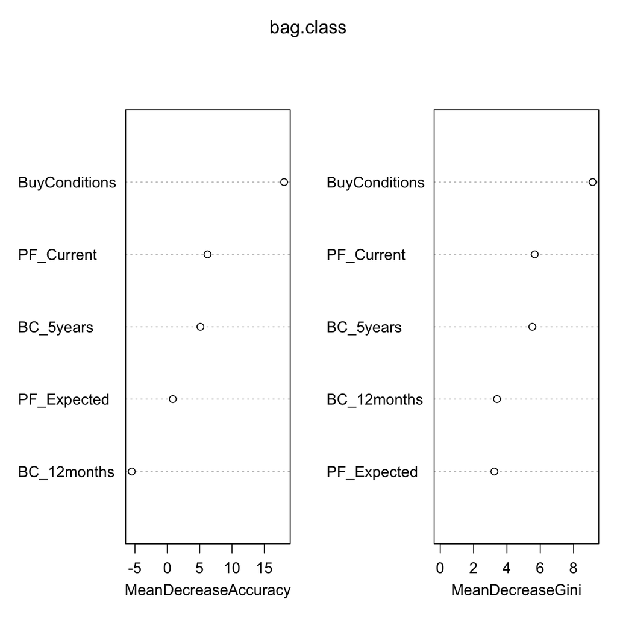

```r
##graphical version
varImpPlot(bag.class)
```

```r
##prediction based on bagging for test data
pred.bag<-predict(bag.class, newdata=test)

##overall test error rate
data_frame2<-cbind(pred.bag,pred.test)

rate2<-data_frame2%>%

  filter(pred.bag==DGS_binary)%>%

  count()/length(pred.bag)

1-rate2
```

```
##       n
## 1 0.534
```

##Random forests

```r
RNGkind(sample.kind = "Rejection")

set.seed(100)

rf.class<-randomForest(factor(DGS_binary)~ PF_Current + PF_Expected + BC_12months + BC_5years + BuyConditions, data=train, mtry=2,importance=TRUE)

rf.class
```

```
##
## Call:
##  randomForest(formula = factor(DGS_binary) ~ PF_Current + PF_Expected +      BC_12months + BC_5years + BuyConditions, data = train, mtry = 2,      importance = TRUE)
##                Type of random forest: classification
##                      Number of trees: 500
## No. of variables tried at each split: 2
##
##         OOB estimate of  error rate: 33.3%
## Confusion matrix:
##    0  1 class.error
## 0 25  9       0.265
## 1 10 13       0.435
```

```r
importance(rf.class)
```

```
##                    0     1 MeanDecreaseAccuracy MeanDecreaseGini
## PF_Current     2.025  3.49                3.577             5.38
## PF_Expected    3.772 -2.98                0.936             3.99
## BC_12months   -1.542 -1.95               -2.833             4.84
## BC_5years     -0.113  5.20                2.832             5.44
## BuyConditions 14.346  5.36               14.247             7.34
```

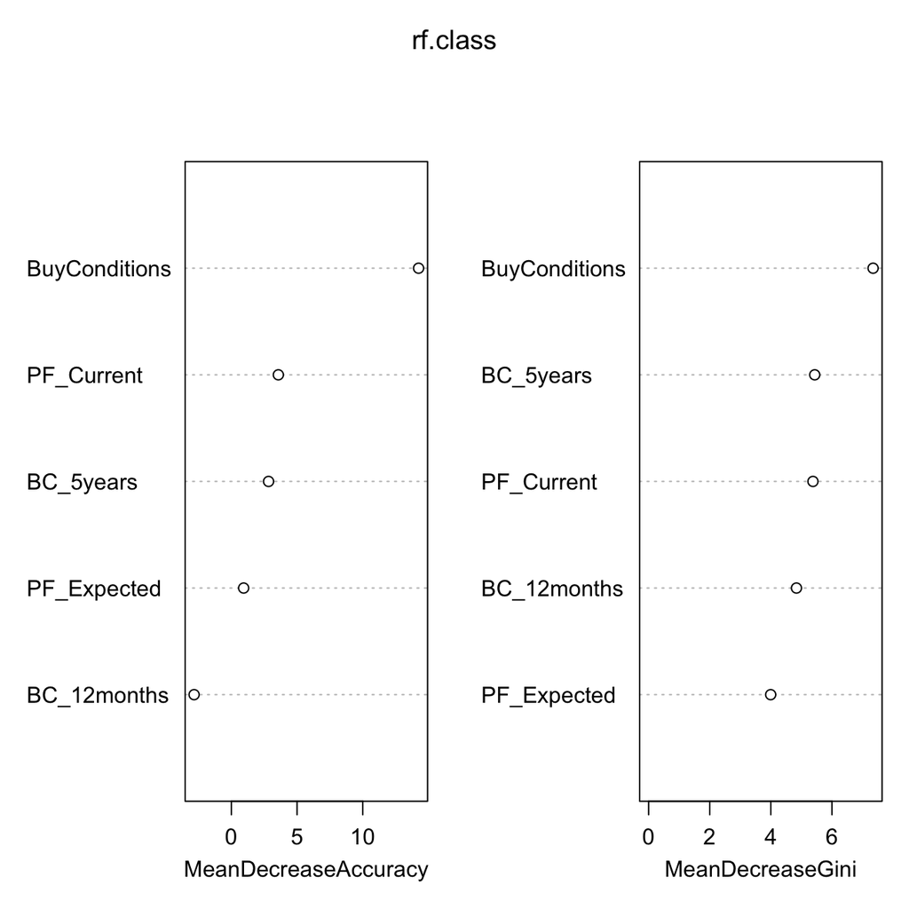

```r
##graphical version
varImpPlot(rf.class)
```

```r
##prediction based on Random forests for test data
pred.rf<-predict(rf.class, newdata=test)

##overall test error rate
data_frame3<-cbind(pred.rf,pred.test)

rate3<-data_frame3%>%

  filter(pred.rf==DGS_binary)%>%

  count()/length(pred.rf)

1-rate3
```

```
##       n
## 1 0.552
```

Bagging and random forest don’t seem to improve the performance of our model. Bagging has a test MSE of 0.5344828 and random forest has a test MSE of 0.5517241. For both bagging and random forest, BuyConditions is found to be the most important variable.

> In conclusion, consumer sentiment does not seem to be as capable of predicting whether bond yield will either increase or decrease as it is of predicting the bond yield value. When we used bagging and random forest, the test MSE’s did not decrease as it did for bond yield, so it seems that bond yield increase or decrease is harder to predict than the value itself, which is surprising. This was surprising because typically you would employ bagging and random forest methods in order to minimize variance, but this may be a result of overfitting to the noise within the data. All the test MSE’s for the classification decision trees hovered around low to mid 50%, and while that is not as bad as it could be, it is difficult to say that consumer sentiment significantly predicts whether bond yield will increase or decrease.